# Regression with R - Final Coursework

Priyan Chandrapala

10/23/2016

## Summary

In this study we analyse a dataset to check we can find a relationship between mpg and other variables with a special focus on manual or automatic.

We start the study with simple linear regression and progress towards multivariable regression.

## Analysis

### liner regression one variable ( mpg~ auto/manual )

We do liner regression between mpg and factor(am). The hypothesis we are testing is below.

H0: There is no difference between the avarages of the two means for Automatic and manual cars

H1: There is a significant difference between the averages for two means for Automatic and Manual cars

```r
fit0<-lm(mpg~factor(am)-1,mtcars)
coef(summary(fit0))
```

```
##             Estimate Std. Error  t value     Pr(>|t|)
## factor(am)0 17.14737   1.124603 15.24749 1.133983e-15
## factor(am)1 24.39231   1.359578 17.94109 1.376283e-17
```

mean mpg for automatic cars is 17.14737 mean mpg for manual cars is 24.39231

### Liner regression with multiple variables and model selection

Now lets try to select multiple variables. We need to check undestand what variables might be the most significant. Here I have selected the variables manually based on the p values. Apart from am the two other variables with the least p values are selected. They are wt and qsec.

```r
coef(summary(lm(mpg~.,mtcars)))
```

```
##                Estimate  Std. Error    t value   Pr(>|t|)
## (Intercept) 12.30337416 18.71788443  0.6573058 0.51812440
## cyl         -0.11144048  1.04502336 -0.1066392 0.91608738
## disp         0.01333524  0.01785750  0.7467585 0.46348865
## hp          -0.02148212  0.02176858 -0.9868407 0.33495531
## drat         0.78711097  1.63537307  0.4813036 0.63527790
## wt          -3.71530393  1.89441430 -1.9611887 0.06325215
## qsec         0.82104075  0.73084480  1.1234133 0.27394127
## vs           0.31776281  2.10450861  0.1509915 0.88142347
## am           2.52022689  2.05665055  1.2254035 0.23398971
## gear         0.65541302  1.49325996  0.4389142 0.66520643
## carb        -0.19941925  0.82875250 -0.2406258 0.81217871
```

Nested model testing is done to check the suitability of the models with the added variables.

```r
fit1<-lm(mpg ~wt-1,mtcars)
fit2<-update(fit1,mpg ~wt+factor(am)-1,mtcars)
fit3<-update(fit2,mpg ~wt+factor(am) + qsec-1 , mtcars)
anova(fit1,fit2,fit3)
```

```
## Analysis of Variance Table
##
## Model 1: mpg ~ wt - 1
## Model 2: mpg ~ wt + factor(am) - 1
## Model 3: mpg ~ wt + factor(am) + qsec - 1
##   Res.Df    RSS Df Sum of Sq       F    Pr(>F)
## 1     31 3936.6
## 2     29  278.3  2    3658.3 302.542 < 2.2e-16 ***
## 3     28  169.3  1     109.0  18.034 0.0002162 ***
## ---
## Signif. codes:  0 '***' 0.001 '**' 0.01 '*' 0.05 '.' 0.1 ' ' 1
```

Here we can see that the model 3 is the most significant

### Confidence intervals

first Lets calcualte the 95% confidence interval for mpg for manual cars. Here I have used the first model fit0<-lm(mpg~factor(am)-1,mtcars)

```r
pe <- coef(summary(fit0))["factor(am)1", "Estimate"]
se <- coef(summary(fit0))["factor(am)1", "Std. Error"]
n <- length(mtcars$mpg)
tstat <- qt(1 - 0.05/2, n - 2)  # n - 2 for model with intercept and slope
pe + c(-1, 1) * (se * tstat)
```

```
## [1] 21.61568 27.16894
```

Now lets see how this confidence interval changes in the multi variable model

```r
pe <- coef(summary(fit3))["factor(am)1", "Estimate"]
se <- coef(summary(fit3))["factor(am)1", "Std. Error"]
n <- length(mtcars$mpg)
tstat <- qt(1 - 0.05/2, n - 2)  # n - 2 for model with intercept and slope
pe + c(-1, 1) * (se * tstat)
```

```
## [1]  0.182881 24.924354
```

## Appendix

### Residaul analysis

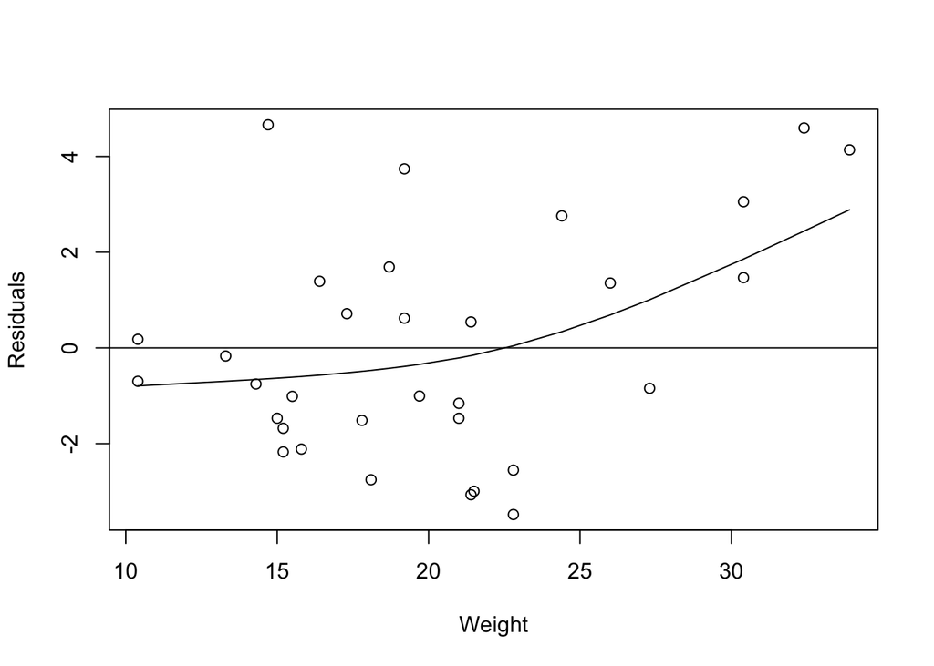

```r
fit3<-lm(mpg ~wt+factor(am)+qsec,mtcars-1)
rs=resid(fit3)
plot(mtcars$mpg,rs,xlab="Weight",ylab="Residuals")
abline(0,0)

smoothingSpline = smooth.spline(mtcars$mpg,rs, spar=1)
lines(smoothingSpline)
```

The residuals are not exatly simmatric over the 0:0 line. This indiate that the model might be effected by unajusted variables.

### Exporitary graphs

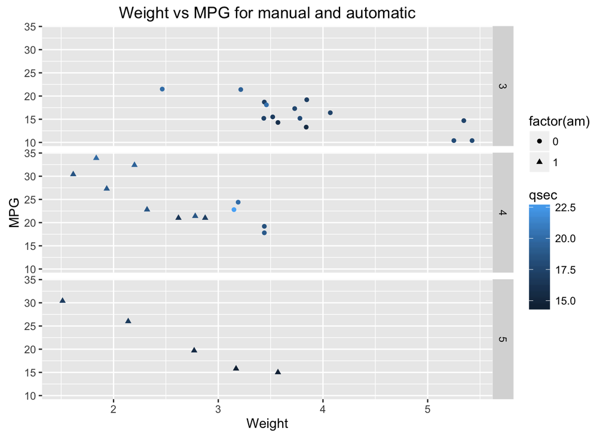

```r
require(ggplot2)
# trangles are manual, dots are automatic
# color is qsec, lighter is higher qsec, darker is lower qsec
# gears: top graph 3, middle 4, bottom 5
g<-ggplot(mtcars,aes(wt,mpg))
g<-g+geom_point(aes(color=qsec,shape=factor(am)))
g<-g+facet_grid(gear ~ .)
g<-g+ggtitle("Weight vs MPG for manual and automatic")
g<-g+xlab("Weight")
g<-g+ylab("MPG")
g
```